# Week5_PCA

### Module 6. Consulting Engagement with the Chilean Government (I)

Representatives of Chilean government (the Ministry of Economic Development and Tourism of Chile) hired a consulting company, trying to improve the tourism industry in the country. Government officials provided some existing data (messy as always!) and expect meaninful insights and recommendations.

**Project objective:**

Based on the data associated to the **15 regions of Chile under the 5 dimensions** considered, you are expected to deliver a report that will include the three sections outlined below:

1. **Perform a Principal Component Analysis (PCA)** for the dataset provided, as presented in the video and complementary example available in this module, such that you can come up with:

a. A ranking for each one of the five dimensions considered, such that regions are ranked within each (five rankings in total).

b. While the main results for each of the five dimensions should be presented first, your methodology and all values obtained (eigenvalues; eigenvectors; weights; results) should be presented in a clear and structured manner as well.

1. **Based on such analysis, you should select 5 to 7 regions to identify and present their main strengths and opportunity areas in a clear and structured manner. Your report should describe the current status of each one of these regions, based on such strengths and opportunity areas. Assume that the client (the Ministry of Economic Development and Tourism of Chile) will consider your report to select a consulting firm to conduct this analysis further.**
2. Based on the information that you will present in 1) and 2) above, plus the information presented in the WEF and OECD references available in this module, select two dimensions that the Chilean government should consider for further investment to improve tourism competitiveness nationwide. Provide a brief rationale that took you to recommend such dimensions.

This first stage of our Case for Analysis is designed to expose you to a real instance, which will demand more than an accurate quantitative analysis to succeed. Think of the document that you will deliver as your preliminary analysis and proposal to deliver to the client, so they evaluate the current and potential work of your consulting team to work further on this.

A key question that you should consider while working on this assignment is: what makes your analysis and recommendations unique, and better, as compared to other ones presented by other consulting teams? Make sure that your document ‘speaks by itself’ to answer this question in a clear and structured manner.

```python
# Import useful libraries
import pandas as pd
import numpy as np
import matplotlib.pyplot as plt
import seaborn as sns
from sklearn.decomposition import PCA
from sklearn.impute import SimpleImputer
from sklearn.preprocessing import StandardScaler
```

```python
# Set additional parameters for charts and tables

# Remove column display limits
pd.set_option('display.max_columns', None)
# pd.set_option('display.height', None)
pd.set_option('display.max_rows', None)
# pd.set_option('display.width', None)
plt.rcParams['figure.figsize'] = [15, 10]
sns.set_style("white")
```

**1. Data Importing and Data Cleaning**

Data cleaning is a serios part of this assignment. This analysis demonstrates that in real life your datasets will not come to you clean and handy, and you will spend a significant amount of time (usually about 80%) on preparing a dataset.

For the purpose of this analysis the given `.xlsx` file was converted as `.csv` without losing the information from the first sheet.

```python
# Read data in csv format, using encoding, and read the third row as column names
chile_data = pd.read_csv('Tourism Chile D1 - D5.csv', encoding = 'ISO-8859-1', header = 3)
```

```python
# Print
chile_data.head()
```

|  | Unnamed: 0 | N° | VARIABLE | CULTURAL EVENTS SCHEDULED THROUGHOUT THE YEAR | NUMBER OF CULTURAL CENTERS | WORLD CULTURAL HERITAGE SITES | NUMBER OF ARCHEOLOGICAL SITES | NATIONAL MONUMENTS | MUSEUMS | % OF POPULATION THAT ATTENDS MUSEUMS | THEATERS | NUMBER OF THEATER PLAYS PER YEAR | LIBRARIES | GALERIES | % OF POPULATION ASSOCIATED TO AN INDIGENOUS GROUP | NUMBER OF EXHIBITS | ARTISTIC EVENTS (MUSIC, DANCE AND FOLKLOR, THEATRE, ETC) PER YEAR | MAJOR SPORTS EVENTS PER YEAR | OBSERVATORIES, ZOOS, AQUARIUMS, BOTANICAL GARDENS | ARTWORK SITES | POPULAR ARCHITECTURE SITES | HISTORICAL SITES | LOCAL MARKETS | CULTURAL SITES LEVEL III (INTERNATIONAL) | CULTURA SITES LEVEL II (NATIONAL) | CULTURAL SITES LEVEL I (LOCAL) | HERITAGE ARCHITECTURAL HOUSES | % OF LAND THAT CORRESPONDS TO FORESTS | NATIONAL PROTECTED SITES (%) | … |
| --- | --- | --- | --- | --- | --- | --- | --- | --- | --- | --- | --- | --- | --- | --- | --- | --- | --- | --- | --- | --- | --- | --- | --- | --- | --- | --- | --- | --- | --- | --- |
| 0 | NaN | XV | Arica y Parinacota | 31.0 | 2 | 0 | 30 | 28 | 4 | 22.1 | 2 | 105 | 12 | 2 | 25.4 | 1 | 0 | 0 | 0 | 4 | 32 | 4 | 3 | 9 | 32 | 7 | 59 | - | 21.9 | … |
| 1 | NaN | I | Tarapacá | 0.0 | 5 | 1 | 13 | 73 | 5 | 20.8 | 2 | 178 | 12 | 1 | 12.6 | 1 | 0 | 0 | 0 | 0 | 34 | 10 | 1 | 6 | 34 | 12 | 0 | 0.2 | 9.1 | … |
| 2 | NaN | II | Antofagasta | 1.0 | 9 | 0 | 28 | 81 | 16 | 27.4 | 8 | 203 | 15 | 2 | 5.7 | 2 | 1 | 0 | 3 | 1 | 24 | 37 | 0 | 4 | 31 | 26 | 63 | - | 2.8 | … |
| 3 | NaN | III | Atacama | 8.0 | 10 | 0 | 8 | 35 | 7 | 20.0 | 0 | 144 | 12 | 0 | 7.5 | 0 | 0 | 0 | 0 | 0 | 18 | 5 | 0 | 2 | 29 | 7 | 33 | - | 2.0 | … |
| 4 | NaN | IV | Coquimbo | 23.0 | 7 | 0 | 2 | 52 | 7 | 18.3 | 4 | 80 | 22 | 2 | 1.7 | 0 | 1 | 0 | 7 | 1 | 69 | 2 | 1 | 0 | 29 | 27 | 97 | 0.8 | 0.4 | … |

```python
# Remove first 2 columns
chile_data.drop(chile_data.iloc[:, 0:2], inplace = True, axis = 1)
```

```python
# Print the whole dataframe
chile_data
# As you can see, we cleaned almost everything, but the last row with the aggregated information must be removed too
```

|  | VARIABLE | CULTURAL EVENTS SCHEDULED THROUGHOUT THE YEAR | NUMBER OF CULTURAL CENTERS | WORLD CULTURAL HERITAGE SITES | NUMBER OF ARCHEOLOGICAL SITES | NATIONAL MONUMENTS | MUSEUMS | % OF POPULATION THAT ATTENDS MUSEUMS | THEATERS | NUMBER OF THEATER PLAYS PER YEAR | LIBRARIES | GALERIES | % OF POPULATION ASSOCIATED TO AN INDIGENOUS GROUP | NUMBER OF EXHIBITS | ARTISTIC EVENTS (MUSIC, DANCE AND FOLKLOR, THEATRE, ETC) PER YEAR | MAJOR SPORTS EVENTS PER YEAR | OBSERVATORIES, ZOOS, AQUARIUMS, BOTANICAL GARDENS | ARTWORK SITES | POPULAR ARCHITECTURE SITES | HISTORICAL SITES | LOCAL MARKETS | CULTURAL SITES LEVEL III (INTERNATIONAL) | CULTURA SITES LEVEL II (NATIONAL) | CULTURAL SITES LEVEL I (LOCAL) | HERITAGE ARCHITECTURAL HOUSES | % OF LAND THAT CORRESPONDS TO FORESTS | NATIONAL PROTECTED SITES (%) | % LAND THAT CORRESPONDS TO HUMAN SETTLEMENTS | TOXIC WASTE DISPOSAL (TONS/100 hab.) | … |
| --- | --- | --- | --- | --- | --- | --- | --- | --- | --- | --- | --- | --- | --- | --- | --- | --- | --- | --- | --- | --- | --- | --- | --- | --- | --- | --- | --- | --- | --- | --- |
| 0 | Arica y Parinacota | 31.0 | 2 | 0 | 30 | 28 | 4 | 22.1 | 2 | 105 | 12 | 2 | 25.4 | 1 | 0 | 0 | 0 | 4 | 32 | 4 | 3 | 9 | 32 | 7 | 59 | - | 21.9 | 0.4600 | 58.000000 | … |
| 1 | Tarapacá | 0.0 | 5 | 1 | 13 | 73 | 5 | 20.8 | 2 | 178 | 12 | 1 | 12.6 | 1 | 0 | 0 | 0 | 0 | 34 | 10 | 1 | 6 | 34 | 12 | 0 | 0.2 | 9.1 | 0.0300 | 76.030000 | … |
| 2 | Antofagasta | 1.0 | 9 | 0 | 28 | 81 | 16 | 27.4 | 8 | 203 | 15 | 2 | 5.7 | 2 | 1 | 0 | 3 | 1 | 24 | 37 | 0 | 4 | 31 | 26 | 63 | - | 2.8 | 0.0300 | 39.560000 | … |
| 3 | Atacama | 8.0 | 10 | 0 | 8 | 35 | 7 | 20.0 | 0 | 144 | 12 | 0 | 7.5 | 0 | 0 | 0 | 0 | 0 | 18 | 5 | 0 | 2 | 29 | 7 | 33 | - | 2.0 | 0.0200 | 40.760000 | … |
| 4 | Coquimbo | 23.0 | 7 | 0 | 2 | 52 | 7 | 18.3 | 4 | 80 | 22 | 2 | 1.7 | 0 | 1 | 0 | 7 | 1 | 69 | 2 | 1 | 0 | 29 | 27 | 97 | 0.8 | 0.4 | 0.3500 | 25.450000 | … |
| 5 | Valparaíso | 14.0 | 37 | 2 | 24 | 161 | 12 | 25.7 | 7 | 322 | 56 | 7 | 3.2 | 3 | 3 | 1 | 4 | 2 | 48 | 21 | 4 | 46 | 90 | 36 | 720 | 6.5 | 2.7 | 2.1100 | 38.460000 | … |
| 6 | Metropolitana | 4.0 | 56 | 0 | 1 | 404 | 35 | 22.5 | 70 | 6558 | 127 | 25 | 4.1 | 30 | 0 | 0 | 3 | 2 | 5 | 9 | 4 | 4 | 85 | 112 | 274 | 6.9 | 0.9 | 7.2500 | 47.030000 | … |
| 7 | O'Higgins | 32.0 | 13 | 1 | 9 | 67 | 6 | 21.9 | 13 | 251 | 36 | 0 | 1.9 | 1 | 7 | 2 | 3 | 16 | 29 | 3 | 1 | 0 | 28 | 15 | 229 | 11.3 | 2.8 | 0.9200 | 27.150000 | … |
| 8 | Maule | 29.0 | 17 | 0 | 1 | 54 | 7 | 11.1 | 9 | 657 | 29 | 1 | 1.6 | 1 | 7 | 0 | 0 | 10 | 27 | 4 | 3 | 0 | 37 | 28 | 19 | 12.7 | 0.6 | 0.4100 | 32.860000 | … |
| 9 | Biobío | 5.0 | 32 | 0 | 0 | 59 | 20 | 18.9 | 12 | 488 | 63 | 7 | 3.9 | 10 | 0 | 0 | 0 | 4 | 13 | 23 | 2 | 0 | 10 | 54 | 135 | 20.7 | 2.8 | 0.9600 | 31.680000 | … |
| 10 | Araucanía | 18.0 | 13 | 0 | 2 | 96 | 5 | 13.2 | 8 | 179 | 58 | 4 | 30.1 | 0 | 5 | 3 | 0 | 13 | 16 | 6 | 10 | 0 | 12 | 31 | 20 | 29.4 | 9.6 | 0.4300 | 36.790000 | … |
| 11 | Los Ríos | 3.0 | 9 | 0 | 1 | 33 | 8 | 16.2 | 3 | 94 | 12 | 2 | 16.7 | 2 | 1 | 0 | 1 | 0 | 10 | 5 | 2 | 0 | 10 | 19 | 55 | 46.1 | 6.9 | 0.3100 | 35.410000 | … |
| 12 | Los Lagos | 1.0 | 24 | 1 | 0 | 64 | 11 | 19.8 | 8 | 272 | 31 | 1 | 20.8 | 2 | 0 | 0 | 0 | 0 | 38 | 3 | 3 | 0 | 57 | 30 | 94 | 56.3 | 15.9 | 0.1800 | 34.770000 | … |
| 13 | Aysén | 0.0 | 4 | 0 | 2 | 17 | 0 | 14.8 | 0 | 49 | 12 | 0 | 21.8 | 0 | 0 | 0 | 0 | 0 | 24 | 2 | 0 | 1 | 20 | 10 | 0 | 44.4 | 39.4 | 0.0200 | 43.890000 | … |
| 14 | Magallanes y Antártica | 0.0 | 3 | 0 | 2 | 45 | 6 | 27.7 | 2 | 4 | 14 | 0 | 22.7 | 3 | 0 | 0 | 0 | 2 | 16 | 16 | 0 | 2 | 24 | 11 | 34 | 20.2 | 57.3 | 0.0400 | 40.580000 | … |
| 15 | NaN | NaN | 241 | 5 | 123 | 1269 | 149 | 300.4 | 148 | 9584 | 511 | 54 | NaN | 56 | 25 | 6 | 21 | 55 | 403 | 150 | 34 | 74 | 528 | 425 | 1832 | 255.4712331 | 175.1 | 13.5195 | 608.394109 | … |

```python
# Remove the last row with aggregated Total data
chile_data = chile_data[:-1]
```

```python
# Print dimensions
chile_data.shape
```

```
(15, 82)
```

```python
# Rename the first column
chile_data = chile_data.rename(columns={'VARIABLE': 'Region'})
```

```python
# Check NaNs in the dataset
# chile_data.isnull().sum(axis = 0)
# Only one NaN (LAND AFFECTED BY WILDFIRES) at the first sight, but it is not exactly true
```

```python
# Types of columns
chile_data.dtypes[0:10]
# When we see each column by type, we can see that not all of them have integers or floats. Some are objects.
# We need to dig into it more
```

```
Region                                            object
CULTURAL EVENTS SCHEDULED THROUGHOUT THE YEAR    float64
NUMBER OF CULTURAL CENTERS                         int64
WORLD CULTURAL HERITAGE SITES                      int64
NUMBER OF ARCHEOLOGICAL SITES                      int64
NATIONAL MONUMENTS                                 int64
MUSEUMS                                            int64
% OF POPULATION THAT ATTENDS MUSEUMS             float64
THEATERS                                           int64
NUMBER OF THEATER PLAYS PER YEAR                   int64
dtype: object
```

```python
# Print only object columns
chile_data.loc[:, chile_data.dtypes == np.object]
# We can see that not all columns are that clean still, so it is important to double check a dataset
```

|  | Region | % OF LAND THAT CORRESPONDS TO FORESTS | LAND AFFECTED BY WILDFIRES | PRESERVED SITES | AVERAGE MONTHLY INCOME (CHILEAN PESOS) | NUMBER OF COLLEGE STUDENTS IN TOURISM RELATED PROGRAMS | NUMBER OF BEDS AVAILABLE IN HOTELS, HOSTELS, B&B, ETC. | NATIONAL TOURISTS ARRIVALS | INTERNATIONAL TOURISTS ARRIVALS | NUMBER OF PEOPLE TRAVELING OUT OF THE COUNTRY | NUMBER OF VEHICLES | VISITORS TO PROTECTED SITES | TOURIST'S ARRIVALS THROUGH BORDER LINES |
| --- | --- | --- | --- | --- | --- | --- | --- | --- | --- | --- | --- | --- | --- |
| 0 | Arica y Parinacota | - | - | - | $ 293,648 | 193 | 6,544 | 97,454 | 34,186 | 1,151,575 | 45,248 | 15,045 | 167,211 |
| 1 | Tarapacá | 0.2 | - | 5 | $ 381,466 | 255 | 11,108 | 235,365 | 40,919 | 19,560 | 81,182 | 17,161 | 434,727 |
| 2 | Antofagasta | - | - | 5 | $ 475,866 | 529 | 19,920 | 413,922 | 84,195 | 22,898 | 112,607 | 315,888 | 115,100 |
| 3 | Atacama | - | NaN | 5 | $ 379,971 | 108 | 9,674 | 168,508 | 14,222 | 2,416 | 55,812 | 24,873 | 2,552 |
| 4 | Coquimbo | 0.8 | 1.50 | 5 | $ 338,014 | 870 | 24,346 | 205,850 | 25,803 | 2,786 | 116,263 | 57,234 | 15,265 |
| 5 | Valparaíso | 6.5 | 6.64 | 5 | $ 311,264 | 3,949 | 44,504 | 430,436 | 106,915 | 317,309 | 316,618 | 146,161 | 436,195 |
| 6 | Metropolitana | 6.9 | 0.04 | 5 | $ 421,484 | 12,881 | 43,634 | 448,887 | 765,681 | 1,091,111 | 1,306,140 | 83,459 | 1,147,039 |
| 7 | O'Higgins | 11.3 | 2.47 | 5 | $ 308,068 | 352 | 14,526 | 73,478 | 7,066 | - | 164,204 | 11,073 | 0 |
| 8 | Maule | 12.7 | 0.82 | 5 | $ 244,231 | 364 | 12,278 | 167,293 | 8,935 | 3,942 | 185,728 | 64,500 | 853 |
| 9 | Biobío | 20.7 | 0.73 | 5 | $ 290,367 | 4,023 | 20,802 | 393,481 | 31,409 | 1,546 | 312,085 | 49,841 | 828 |
| 10 | Araucanía | 29.4 | 0.16 | 5 | $ 251,081 | 709 | 26,140 | 200,377 | 38,524 | 130,713 | 124,956 | 228,921 | 112,246 |
| 11 | Los Ríos | 46.1 | 0.14 | - | $ 268,648 | 444 | 12,846 | 113,900 | 16,070 | 11,145 | 51,811 | 376 | 0 |
| 12 | Los Lagos | 56.3 | 0.00 | 7 | $ 291,431 | 856 | 35,548 | 275,043 | 105,048 | 259,411 | 129,882 | 486,725 | 192,977 |
| 13 | Aysén | 44.4 | 0.01 | 6 | $ 418,044 | 64 | 8,020 | 28,584 | 10,763 | 90,876 | 19,348 | 32,030 | 56,201 |
| 14 | Magallanes y Antártica | 20.2 | 0.01 | 5 | $ 572,203 | 380 | 12,436 | 84,034 | 109,092 | 262,190 | 46,336 | 283,629 | 388,598 |

```python
# Remove $ symbol
chile_data = chile_data.replace(r'[<$]', '', regex = True)
```

```python
# Remove commas from numbers
chile_data = chile_data.replace(',','', regex = True)
```

```python
# Remove `-` character
chile_data = chile_data.replace('-','', regex = True)
```

```python
# Replace empty values with NaNs
chile_data = chile_data.replace(r'^\s*$', np.nan, regex = True)
```

```python
# Check NaNs in the dataset again
```

Now after replacement we have NaNs in 4 columns:

- % OF LAND THAT CORRESPONDS TO FORESTS (3 NaNs)
- LAND AFFECTED BY WILDFIRES (4 NaNs)
- PRESERVED SITES (2 NaNs)
- NUMBER OF PEOPLE TRAVELING OUT OF THE COUNTRY (1 NaN)

Ideally, we need to request this data from the client. It is a small dataset, so these numbers are important.

Additional information:

In many cases, some predictors have no values for a given sample. **These missing data could be structurally missing.**

**It is important to understand why the values are missing**. First and foremost, it is important to know if the pattern of missing data is related to the outcome. **This is called “informative missingness” since the missing data pattern is instructional on its own.** Informative missingness can induce significant bias in the model.

**If we do not remove the missing data, there are two general approaches.** First, a few predictive models, especially tree-based techniques, can specifically account for missing data. **Alternatively, missing data can be imputed.** In this case, we can use information in the training set predictors to, in essence, estimate the values of other predictors. This amounts to a predictive model within a predictive model.

**If the number of predictors affected by missing values is small, an exploratory analysis of the relationships between the predictors is a good idea. For example, visualizations or methods like PCA can be used to determine if there are strong relationships between the predictors. If a variable with missing values is highly correlated with another predictor that has few missing values, a focused model can often be effective for imputation.**

Source: **Applied Predictive Modeling** (M.Kuhn and K.Johnson) (www.appliedpredictivemodeling.com)

There are several ways how to handle the missing data in our dataset:

1. As we said about - ask the client to provide additional data
2. We have 82 variables. If we knew that these variables are not that important we cound drop it. But we do not know it yet.
3. Impute these variables, replacing NaN with some values. It can be a mean value of the column or a more advanced approach. You can read about imputation addtionally here:

https://machinelearningmastery.com/handle-missing-data-python/

https://scikit-learn.org/stable/modules/impute.html

But for now we will start from a simple imputation.

```python
# Impute data in four columns
imputer = SimpleImputer(missing_values = np.nan, strategy = 'mean')
## carry out YOUR Imputation here

chile_data[['% OF LAND THAT CORRESPONDS TO FORESTS',
            'LAND AFFECTED BY WILDFIRES',
            'PRESERVED SITES',
            'NUMBER OF PEOPLE TRAVELING OUT OF THE COUNTRY']] = imputer.fit_transform(chile_data[['% OF LAND THAT CORRESPONDS TO FORESTS',
                                                                                                  'LAND AFFECTED BY WILDFIRES',
            'PRESERVED SITES',
            'NUMBER OF PEOPLE TRAVELING OUT OF THE COUNTRY']])
```

```python
# Check NaNs in the dataset
chile_data.isnull().sum(axis = 0)[0:10]
# As we can see below, we do not have any missing values anymore
```

```
Region                                           0
CULTURAL EVENTS SCHEDULED THROUGHOUT THE YEAR    0
NUMBER OF CULTURAL CENTERS                       0
WORLD CULTURAL HERITAGE SITES                    0
NUMBER OF ARCHEOLOGICAL SITES                    0
NATIONAL MONUMENTS                               0
MUSEUMS                                          0
% OF POPULATION THAT ATTENDS MUSEUMS             0
THEATERS                                         0
NUMBER OF THEATER PLAYS PER YEAR                 0
dtype: int64
```

```python
# Let's check the correlation
# cor = chile_data.corr()
# cor.loc[:,:] = np.tril(cor, k=-1)
# cor = cor.stack()
# cor[(cor > 0.55) | (cor < -0.55)]
# We can see a lot of correlated variables here
```

```python
# If possible plot your Heatmap of correlations here
# This heatmap will not tell us too much, if you have more numbers of variables. but if we had less variables, it would be useful.
# We will keep it as an example
```

[output not shown]

Usually, we try to avoid the nulticollinearity and drop some highly correlated and less important variables. However, the **Principal Component Analysis (as a dimensionality reduction technique) will handle this problem.**

```python
# Convert object columns to numeric

# Select columns
cols = ['AVERAGE MONTHLY INCOME (CHILEAN PESOS)',
          'NUMBER OF COLLEGE STUDENTS IN TOURISM RELATED PROGRAMS',
          'NUMBER OF BEDS AVAILABLE IN HOTELS, HOSTELS, B&B, ETC.',
          'NATIONAL TOURISTS ARRIVALS',
          'INTERNATIONAL TOURISTS ARRIVALS',
          'NUMBER OF VEHICLES',
          'VISITORS TO PROTECTED SITES',
          "TOURIST'S ARRIVALS THROUGH BORDER LINES"]

# Convert
chile_data[cols] = chile_data[cols].apply(pd.to_numeric, errors = 'coerce', axis = 1)
# Now all our columns are integers or floats
```

**2. Exploratory data analysis**

Multiple types of analysis can be done here with with a data frame (82 * 15). At the same time, it is great to understand exactly what should be analyzed here.

For now just several example of basic visualizations are added here.

[figure not shown]

```python
# Create a barchart and rotate axes, putting regions in alphabetical order
# The same simple analysis can be applied to any of 80+ variables
```

**3. Principal Component Analysis**

PCA is a commonly used data reduction technique (Abdi and Williams 2010). This method seeks to find linear combinations of the predictors, known as principal components (PCs), which capture the most possible variance. The first PC is defined as the linear combination of the predictors that captures the most variability of all possible linear combinations. Then, **subsequent PCs are derived such that these linear combinations capture the most remaining variability while also being uncorrelated with all previous PCs.**

**The primary advantage of PCA, and the reason that it has retained its popularity as a data reduction method, is that it creates components that are uncorrelated**. As mentioned earlier in this chapter, some predictive models prefer predictors to be uncorrelated (or at least low correlation) in order to find solutions and to improve the model’s numerical stability. PCA preprocessing creates new predictors with desirable characteristics for these kinds of models.

**While PCA delivers new predictors with desirable characteristics, it must be used with understanding and care.** Notably, practitioners must understand that PCA seeks predictor-set variation without regard to any further understanding of the predictors (i.e., measurement scales or distributions) or to knowledge of the modeling objectives (i.e., response variable). **Hence, without proper guidance, PCA can generate components that summarize characteristics of the data that are irrelevant to the underlying structure of the data and also to the ultimate modeling objective. Because PCA seeks linear combinations of predictors that maximize variability, it will naturally first be drawn to summarizing predictors that have more variation. If the original predictors are on measurement scales that differ in orders of magnitude (consider demographic predictors such as income level (in dollars) and height (in feet)), then the first few components will focus on summarizing the higher magnitude predictors (e.g., income), while latter components will summarize lower variance predictors (e.g., height). This means that the PC weights will be larger for the higher variability predictors on the first few components. In addition, it means that PCA will be focusing its efforts on identifying the data structure based on measurement scales rather than based on the important relationships within the data for the current problem.**

**For most data sets, predictors are on different scales. In addition, predictors may have skewed distributions. Hence, to help PCA avoid summarizing distributional differences and predictor scale information, it is best to first transform skewed predictors and then center and scale the predictors prior to performing PCA.** Centering and scaling enables PCA to find the underlying relationships in the data without being influenced by the original measurement scales.

**The second caveat of PCA is that it does not consider the modeling objective or response variable when summarizing variability. Because PCA is blind to the response, it is an unsupervised technique. If the predictive relationship between the predictors and response is not connected to the predictors’ variability, then the derived PCs will not provide a suitable relationship with the response.** In this case, a supervised technique, like PLS, will derive components while simultaneously considering the corresponding response.

Once we have decided on the appropriate transformations of the predictor variables, we can then apply PCA. **For data sets with many predictor variables, we must decide how many components to retain. A heuristic approach for determining the number of components to retain is to create a scree plot, which contains the ordered component number (x-axis) and the amount of summarized variability (y-axis). For most data sets, the first few PCs will summarize a majority of the variability, and the plot will show a steep descent; variation will then taper off for the remaining components. Generally, the component number prior to the tapering off of variation is the maximal component that is retained.**

Another exploratory use of PCA is characterizing which predictors are associated with each component. Recall that each component is a linear combination of the predictors and the coefficient for each predictor is called the **loading. Loadings close to zero indicate that the predictor variable did not contribute much to that component.**

Source: **Applied Predictive Modeling** (M.Kuhn and K.Johnson) (www.appliedpredictivemodeling.com)

**Naturally, the first PC (PC1) captures the most variance followed by PC2, then PC3, etc. We can identify which of our original features contribute to the PCs by assessing the loadings.**

The primary goal in PCA is dimension reduction (in this case, feature reduction). In essence, we want to come out of PCA with fewer components than original features, and with the caveat that these components explain us as much variation as possible about our data. But how do we decide how many PCs to keep? Do we keep the first 10, 20, or 40 PCs? There are three common approaches in helping to make this decision:

- Eigenvalue criterion
- Proportion of variance explained criterion
- Scree plot criterion

**Eigenvalue criterion.** The sum of the eigenvalues is equal to the number of variables entered into the PCA; however, the eigenvalues will range from greater than one to near zero. An eigenvalue of 1 means that the principal component would explain about one variable’s worth of the variability. The rationale for using the eigenvalue criterion is that each component should explain at least one variable’s worth of the variability, and therefore, the eigenvalue criterion states that only components with eigenvalues greater than 1 should be retained.

**Proportion of variance explained criterion.** The proportion of variance explained (PVE) identifies the optimal number of PCs to keep based on the total variability that we would like to account for.

**Scree plot criterion.** A scree plot shows the eigenvalues or PVE for each individual PC. Most scree plots look broadly similar in shape, starting high on the left, falling rather quickly, and then flattening out at some point. This is because the first component usually explains much of the variability explain a moderate amount, and the latter components only explain a small fraction of the overall variability.

**Traditional PCA has a few disadvantages worth keeping in mind. First, PCA can be highly affected by outliers. There have been many robust variants of PCA that act to iteratively discard data points that are poorly described by the initial components. Also, note that our PC directions are linear. Consequently, traditional PCA does not perform as well in very high dimensional space where complex nonlinear patterns often exist.**

Source: **Hands-On Machine Learning with R** (B. Boehmke and B. Greenwell) (https://bradleyboehmke.github.io/HOML/pca.html)

```python
# Finally, we need to standardize data for applying PCA

# Create a copy
chile_data_s = chile_data.copy()

# Standardize
scaler = StandardScaler()
```

```python
chile_data_s.loc[:, chile_data_s.columns != 'Region'] = scaler.fit_transform(chile_data_s.loc[:, chile_data_s.columns != 'Region'])

# Set region as an index column
chile_data_s = chile_data_s.set_index('Region')
```

**3.1. Eigenvalues and eigenvectors**

```python
# Calculate eigenvalues and vectors
cov_mat = np.cov(chile_data_s.T)
eig_val, eig_vec = np.linalg.eig(cov_mat)

# Print
# print('Eigenvectors \n%s' %eig_vec)
# print('\nEigenvalues \n%s' %eig_val)
```

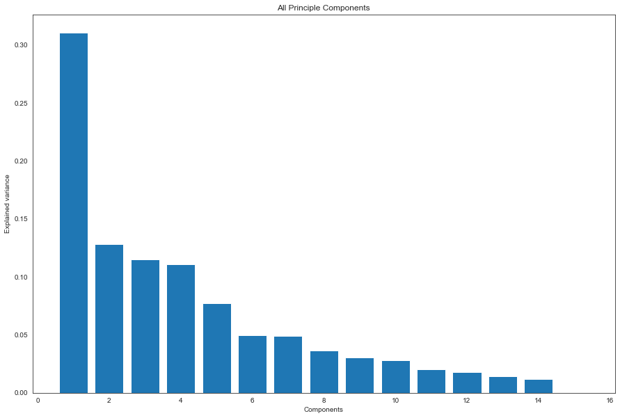

```python
# Run PCA and fit the model
myPCA = PCA()
x     = myPCA.fit(chile_data_s)

# Plotting the varaince explained by each component
plt.bar(range(1,len(x.explained_variance_ )+1),x.explained_variance_ratio_)
plt.ylabel('Explained variance')
plt.xlabel('Components')
plt.title('All Principle Components')
pass
```

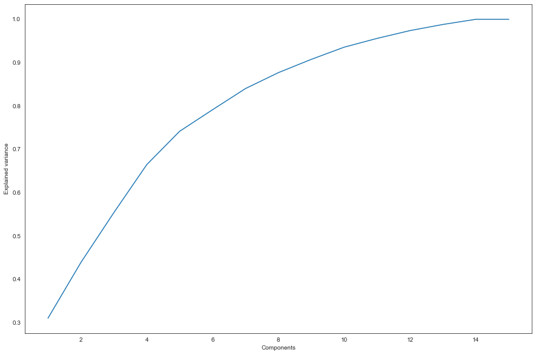

```python
# Deciding on the number of principal componenets to chose
plt.plot(range(1, len(x.explained_variance_)+1), x.explained_variance_ratio_.cumsum())
plt.ylabel('Explained variance')
plt.xlabel('Components')
pass
```

```python
# Calculate the numeric values of principal components
x.explained_variance_ratio_.cumsum()
```

```
array([0.31056255, 0.43909692, 0.55395713, 0.66474306, 0.74173449,
       0.79144989, 0.8402379 , 0.87698473, 0.90761689, 0.93576086,
       0.95599501, 0.97398201, 0.98811612, 1.        , 1.        ])
```

Here you can see that we have 15 principal components in our case. And the total sum of the explained variance increases with each component, but at the same time the majority of variance explained by several first components.

For instance, you can see that the principle component 1 explains about 30% of variance, while principle components 6 and 7 explain about 5% each.

Hence, we do not need all of them and **will use only first 7 components, which explain 84% of variance.**

So, **instead of 80+ columns in our dataset we have 7 uncorrelated components**, which make the analysis easier.

Now we need to understand **how much different features contribute to our principal components.**

```python
# Explore the importance of each feature for principle components
pca = PCA(n_components = 7).fit(chile_data_s)
```

```python
vars_ = pca.explained_variance_ratio_
c_names = chile_data_s.columns
sum_ = 0
```

```python
print('Variance:  Projected dimension')
print('------------------------------')
for idx, row in enumerate(pca.components_):
    output = 100.0*vars_[idx]
    output = '{0:4.1f}%:    '.format(100.0 * vars_[idx])
    output += " + ".join("{0:5.2f} * {1:s}".format(val, name) \
                      for val, name in zip(row, c_names))
    sum_ += 100*vars_[idx]
    print(output)

print('Total variance explained by the 7 components {0:4.1f}%'.format(sum_))
# Total variance explained by the 7 components 84.0%
```

```
Variance:  Projected dimension
------------------------------
31.1%:    -0.00 * CULTURAL EVENTS SCHEDULED THROUGHOUT THE YEAR +  0.18 * NUMBER OF CULTURAL CENTERS +  0.04 * WORLD CULTURAL HERITAGE SITES + -0.01 * NUMBER OF ARCHEOLOGICAL SITES +  0.19 * NATIONAL MONUMENTS +  0.18 * MUSEUMS +  0.04 * % OF POPULATION THAT ATTENDS MUSEUMS +  0.18 * THEATERS +  0.1…
12.9%:    -0.21 * CULTURAL EVENTS SCHEDULED THROUGHOUT THE YEAR + -0.02 * NUMBER OF CULTURAL CENTERS + -0.13 * WORLD CULTURAL HERITAGE SITES +  0.00 * NUMBER OF ARCHEOLOGICAL SITES +  0.05 * NATIONAL MONUMENTS +  0.08 * MUSEUMS +  0.12 * % OF POPULATION THAT ATTENDS MUSEUMS +  0.07 * THEATERS +  0.1…
11.5%:    -0.07 * CULTURAL EVENTS SCHEDULED THROUGHOUT THE YEAR +  0.01 * NUMBER OF CULTURAL CENTERS +  0.20 * WORLD CULTURAL HERITAGE SITES +  0.13 * NUMBER OF ARCHEOLOGICAL SITES +  0.00 * NATIONAL MONUMENTS + -0.04 * MUSEUMS +  0.19 * % OF POPULATION THAT ATTENDS MUSEUMS + -0.07 * THEATERS + -0.0…
11.1%:    -0.06 * CULTURAL EVENTS SCHEDULED THROUGHOUT THE YEAR +  0.06 * NUMBER OF CULTURAL CENTERS + -0.02 * WORLD CULTURAL HERITAGE SITES + -0.16 * NUMBER OF ARCHEOLOGICAL SITES +  0.03 * NATIONAL MONUMENTS + -0.00 * MUSEUMS + -0.12 * % OF POPULATION THAT ATTENDS MUSEUMS +  0.05 * THEATERS +  0.0…
 7.7%:    -0.13 * CULTURAL EVENTS SCHEDULED THROUGHOUT THE YEAR +  0.05 * NUMBER OF CULTURAL CENTERS +  0.06 * WORLD CULTURAL HERITAGE SITES + -0.06 * NUMBER OF ARCHEOLOGICAL SITES + -0.06 * NATIONAL MONUMENTS +  0.08 * MUSEUMS + -0.03 * % OF POPULATION THAT ATTENDS MUSEUMS + -0.03 * THEATERS + -0.0…
 5.0%:     0.17 * CULTURAL EVENTS SCHEDULED THROUGHOUT THE YEAR + -0.05 * NUMBER OF CULTURAL CENTERS +  0.11 * WORLD CULTURAL HERITAGE SITES +  0.25 * NUMBER OF ARCHEOLOGICAL SITES +  0.00 * NATIONAL MONUMENTS + -0.08 * MUSEUMS +  0.01 * % OF POPULATION THAT ATTENDS MUSEUMS + -0.01 * THEATERS +  0.0…
 4.9%:     0.12 * CULTURAL EVENTS SCHEDULED THROUGHOUT THE YEAR + -0.07 * NUMBER OF CULTURAL CENTERS + -0.08 * WORLD CULTURAL HERITAGE SITES + -0.19 * NUMBER OF ARCHEOLOGICAL SITES + -0.01 * NATIONAL MONUMENTS + -0.08 * MUSEUMS + -0.12 * % OF POPULATION THAT ATTENDS MUSEUMS +  0.05 * THEATERS +  0.0…
Total variance explained by the 7 components 84.0%
```

```python
# We also can see this information for each component separately
# For instance, these are results for the Principal Component 1 (sorted)
pd.DataFrame(np.column_stack((chile_data_s.columns, pca.components_[0]))).sort_values(by = 1, ascending = False)[0:10]
# The same logic can be applied to all other principal components
```

|  | 0 | 1 |
| --- | --- | --- |
| 55 | NUMBER OF COLLEGE STUDENTS IN TOURISM RELATED ... | 0.190521 |
| 75 | NUMBER OF VEHICLES | 0.190228 |
| 4 | NATIONAL MONUMENTS | 0.189368 |
| 10 | GALERIES | 0.189226 |
| 26 | % LAND THAT CORRESPONDS TO HUMAN SETTLEMENTS | 0.189172 |
| 56 | AVERAGE NUMBER OF GRADUATES IN TOURISM-RELATED... | 0.188437 |
| 58 | CERTIFIED WORKERS ON HIGHLY-COMPETITIVE TOURIS... | 0.186791 |
| 22 | CULTURAL SITES LEVEL I (LOCAL) | 0.186464 |
| 54 | TOURISM-ORIENTED INSTITUTIONS | 0.185947 |
| 66 | NUMBER OF CERTIFIED CONSULTANTS FOR TOURISM-RE... | 0.185657 |

```python
# Calculate loadings
myPCA = PCA(n_components = 7)
pca_model = myPCA.fit(chile_data_s)

# Print
# print("The loadings are are \n {}".format(pca_model.components_))
```

```python
# Calculate factor scores
pca_model = myPCA.fit_transform(chile_data_s)
PCcomponents = pd.DataFrame(data = pca_model, columns = ['PC1', 'PC2', 'PC3', 'PC4', 'PC5', 'PC6', 'PC7'])
print("\n The Factor scores are")
PCcomponents
```

```
 The Factor scores are
```

|  | PC1 | PC2 | PC3 | PC4 | PC5 | PC6 | PC7 |
| --- | --- | --- | --- | --- | --- | --- | --- |
| 0 | -2.386142 | 1.128396 | 0.417084 | -1.039372 | -2.383579 | 5.560673 | 0.896446 |
| 1 | -1.603717 | 2.205502 | 0.000489 | -3.106017 | 1.359288 | 2.146064 | -0.009668 |
| 2 | -1.163348 | 3.041472 | 0.920221 | -3.063266 | 1.643872 | -1.248495 | -3.558966 |
| 3 | -3.022894 | 1.686132 | -1.287520 | -3.948946 | 1.601311 | 0.192783 | -1.124276 |
| 4 | 0.071800 | -3.459654 | 1.681821 | -3.193220 | 1.184838 | -2.570795 | 4.848208 |
| 5 | 5.666810 | -5.185133 | 7.767526 | -1.476143 | -1.618477 | 0.063266 | -2.100251 |
| 6 | 16.071582 | 4.590960 | -2.013523 | 1.269896 | -1.218331 | 0.133082 | 1.318211 |
| 7 | -0.533601 | -4.130965 | -2.604111 | -1.666633 | -1.291375 | 0.430387 | 0.879329 |
| 8 | -0.906211 | -3.216091 | -3.517245 | 0.026947 | -0.489855 | 0.118975 | 0.163107 |
| 9 | 2.200100 | -0.453991 | -3.581660 | -0.554127 | 2.180578 | -2.483251 | -2.047424 |
| 10 | -1.152331 | -4.064711 | -2.573562 | 5.555666 | -2.773524 | -0.040094 | -2.429809 |
| 11 | -2.270740 | -0.234031 | -2.562392 | 0.799648 | 1.506049 | 0.456833 | 0.681446 |
| 12 | -0.571975 | 0.292343 | 3.611886 | 6.352109 | 6.280926 | 1.319659 | 0.674149 |
| 13 | -6.015841 | 2.613051 | 0.379445 | 2.969578 | -2.191594 | -1.956671 | 1.752658 |
| 14 | -4.383492 | 5.186719 | 3.361541 | 1.073879 | -3.790125 | -2.122415 | 0.056839 |

Finally, we can visualize an example how variables can contribute to diffent principal components.

For instance, we can pick several variables and see how does each variable contribute to each of our seven components.

In our specific case we selected `CULTURAL HERITAGE`, `NATURAL RESOURCES`, `WORKFORCE DEVELOPMENT`, `TOURISM INFRASTRUCTURE`, and `TOURISM MOBILITY`.

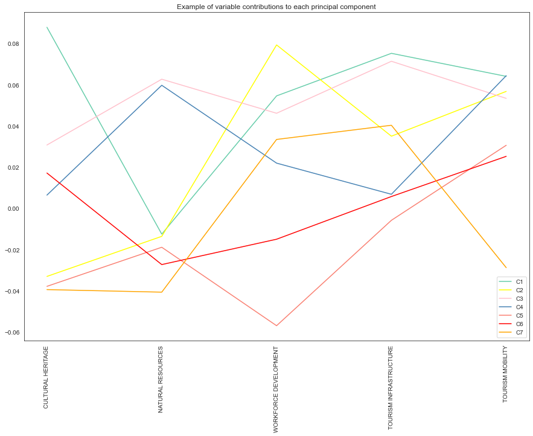

```python
# Example of different variables in each component

# Fit the model
myPCA = PCA(n_components = 7)
pca_model = myPCA.fit(chile_data_s)
y_axis = [0,0,0,0,0,0,0]
for i in range(0,7):
    y_axis[i]=[np.mean(pca_model.components_[i][0:24]), np.mean(pca_model.components_[i][24:47]),
               np.mean(pca_model.components_[i][47:59]), np.mean(pca_model.components_[i][59:69]),
               np.mean(pca_model.components_[i][69:81])]
# Plot
x_axis = ['CULTURAL HERITAGE', 'NATURAL RESOURCES', 'WORKFORCE DEVELOPMENT', 'TOURISM INFRASTRUCTURE', 'TOURISM MOBILITY']
plt.plot(x_axis,y_axis[0], color = 'mediumaquamarine', label = "C1")
plt.plot(x_axis,y_axis[1], color = 'yellow', label = "C2")
plt.plot(x_axis,y_axis[2], color = 'pink', label = "C3")
plt.plot(x_axis,y_axis[3], color = 'steelblue', label = "C4")
plt.plot(x_axis,y_axis[4], color = 'salmon', label = "C5")
plt.plot(x_axis,y_axis[5], color = 'red', label = "C6")
plt.plot(x_axis,y_axis[6], color = 'orange', label = "C7")
plt.xticks(rotation = 90)
plt.title('Example of variable contributions to each principal component')
plt.legend()
pass
```

**4. Developing a scoring system for 5 dimensions**

**Developing a scoring methodology is the most tricky part of the assignment and should be taken carefully**.

Different consultants can offer different scoring methodologies and argue that their approach is correct.

However, this is an example of a scoring system, which can be developed as a part of this assignment.

**Methodology steps:**

**Step 1 - Calculate a weighted average for each variable in principal components.**

Multiply the percentage value of the explained variance by the percentage value of a feature in the selected principal component. As a result, a **weighted average** will be a new column in the dataframe with principal components.

```python
# Creating a dataframe of weights
weights = pd.DataFrame(np.column_stack((chile_data_s.columns, pca_model.components_[0] *
                                        pca_model.explained_variance_ratio_[0],
                                        pca_model.components_[1] * pca_model.explained_variance_ratio_[1],
                                        pca_model.components_[2] * pca_model.explained_variance_ratio_[2],
                                        pca_model.components_[3] * pca_model.explained_variance_ratio_[3],
                                        pca_model.components_[4] * pca_model.explained_variance_ratio_[4],
                                        pca_model.components_[5] * pca_model.explained_variance_ratio_[5],
                                        pca_model.components_[6] * pca_model.explained_variance_ratio_[6])))
weights = weights.set_index(0)

# Create a weighted average
weights['weighted_average'] = weights.sum(axis = 1)/np.sum(pca_model.explained_variance_ratio_)

# Print
weights.head()
```

| 0 | 1 | 2 | 3 | 4 | 5 | 6 | 7 | weighted_average |
| --- | --- | --- | --- | --- | --- | --- | --- | --- |
| CULTURAL EVENTS SCHEDULED THROUGHOUT THE YEAR | -0.0010135 | -0.026766 | -0.00772552 | -0.00715039 | -0.0100109 | 0.00849465 | 0.00587723 | -0.045576 |
| NUMBER OF CULTURAL CENTERS | 0.0571644 | -0.00259764 | 0.000907509 | 0.00659591 | 0.0036928 | -0.00260661 | -0.00364229 | 0.070830 |
| WORLD CULTURAL HERITAGE SITES | 0.0119041 | -0.0165681 | 0.0228346 | -0.0018949 | 0.0042953 | 0.00555241 | -0.003667 | 0.026726 |
| NUMBER OF ARCHEOLOGICAL SITES | -0.00224659 | 9.958e-05 | 0.0151014 | -0.0179738 | -0.00486953 | 0.0123346 | -0.00910945 | -0.007931 |
| NATIONAL MONUMENTS | 0.0588106 | 0.0068198 | 0.000424673 | 0.00349642 | -0.00427658 | 3.51305e-05 | -0.000404655 | 0.077246 |

**Step 2. Calculate a score for each dimension.**

Multiply weighted average of a variable by each standartized value in each column and sum up results, receiving a final score.

```python
# Example
chile_data_s.head(1)
```

| Region | CULTURAL EVENTS SCHEDULED THROUGHOUT THE YEAR | NUMBER OF CULTURAL CENTERS | WORLD CULTURAL HERITAGE SITES | NUMBER OF ARCHEOLOGICAL SITES | NATIONAL MONUMENTS | MUSEUMS | % OF POPULATION THAT ATTENDS MUSEUMS | THEATERS | NUMBER OF THEATER PLAYS PER YEAR | LIBRARIES | GALERIES | % OF POPULATION ASSOCIATED TO AN INDIGENOUS GROUP | NUMBER OF EXHIBITS | ARTISTIC EVENTS (MUSIC, DANCE AND FOLKLOR, THEATRE, ETC) PER YEAR | MAJOR SPORTS EVENTS PER YEAR | OBSERVATORIES, ZOOS, AQUARIUMS, BOTANICAL GARDENS | ARTWORK SITES | POPULAR ARCHITECTURE SITES | HISTORICAL SITES | LOCAL MARKETS | CULTURAL SITES LEVEL III (INTERNATIONAL) | CULTURA SITES LEVEL II (NATIONAL) | CULTURAL SITES LEVEL I (LOCAL) | HERITAGE ARCHITECTURAL HOUSES | % OF LAND THAT CORRESPONDS TO FORESTS | NATIONAL PROTECTED SITES (%) | % LAND THAT CORRESPONDS TO HUMAN SETTLEMENTS | TOXIC WASTE DISPOSAL (TONS/100 hab.) | NUMBER OF ENVIRONMENTAL COMPLAINTS PRESENTED | … |
| --- | --- | --- | --- | --- | --- | --- | --- | --- | --- | --- | --- | --- | --- | --- | --- | --- | --- | --- | --- | --- | --- | --- | --- | --- | --- | --- | --- | --- | --- | --- |
| Arica y Parinacota | 1.672984 | -0.959349 | -0.559017 | 2.121142 | -0.617597 | -0.721316 | 0.440365 | -0.475143 | -0.335687 | -0.724558 | -0.261024 | 1.389477 | -0.368577 | -0.668153 | -0.454859 | -0.6799 | 0.067176 | 0.326242 | -0.61667 | 0.294619 | 0.360486 | -0.136165 | -0.834058 | -0.355859 | 0.0 | 0.643982 | -0.248227 | 1.426648 | -0.576151 | … |

As a result, we multiply:

- `weighted average` for `CULTURAL EVENTS SCHEDULED THROUGHOUT THE YEAR` (-0.045576) in the dataframe `weights` by each value in the `CULTURAL EVENTS SCHEDULED THROUGHOUT THE YEAR` column in the dataframe `chile_data_s`.
- Do the same for all weighted averages and columns in respective dataframe
- Sum up the product of multiplications and **receive the score for the first dimension**

```python
# StandardScaler = X - mean(x)/ sd(x)
```

```python
# Ranking for dimension 1: CULTURAL HERITAGE AND EVENTS

# Create a dataframe for relevant variables
dim1 = chile_data_s.iloc[:, 0:24].mul(weights['weighted_average'][0:24], axis = 1)

# Create a score ranking
dim1['Ranking 1'] = dim1.sum(axis = 1)

# Sort by score
dim1.sort_values(by = 'Ranking 1', ascending = False).head()
```

| Region | CULTURAL EVENTS SCHEDULED THROUGHOUT THE YEAR | NUMBER OF CULTURAL CENTERS | WORLD CULTURAL HERITAGE SITES | NUMBER OF ARCHEOLOGICAL SITES | NATIONAL MONUMENTS | MUSEUMS | % OF POPULATION THAT ATTENDS MUSEUMS | THEATERS | NUMBER OF THEATER PLAYS PER YEAR | LIBRARIES | GALERIES | % OF POPULATION ASSOCIATED TO AN INDIGENOUS GROUP | NUMBER OF EXHIBITS | ARTISTIC EVENTS (MUSIC, DANCE AND FOLKLOR, THEATRE, ETC) PER YEAR | MAJOR SPORTS EVENTS PER YEAR | OBSERVATORIES, ZOOS, AQUARIUMS, BOTANICAL GARDENS | ARTWORK SITES | POPULAR ARCHITECTURE SITES | HISTORICAL SITES | LOCAL MARKETS | CULTURAL SITES LEVEL III (INTERNATIONAL) | CULTURA SITES LEVEL II (NATIONAL) | CULTURAL SITES LEVEL I (LOCAL) | HERITAGE ARCHITECTURAL HOUSES | Ranking 1 |
| --- | --- | --- | --- | --- | --- | --- | --- | --- | --- | --- | --- | --- | --- | --- | --- | --- | --- | --- | --- | --- | --- | --- | --- | --- | --- |
| Metropolitana | 0.028078 | 0.192903 | -0.014940 | 0.005556 | 0.269217 | 0.214340 | 0.018570 | 0.266501 | 0.287588 | 0.180319 | 0.259461 | -0.008320 | 0.269909 | 0.03980 | 0.018823 | 0.008948 | 0.019085 | -0.001139 | 0.000772 | 0.009099 | -0.001584 | 0.180688 | 0.233427 | 0.028090 | 2.505190 |
| Valparaíso | -0.010561 | 0.101121 | 0.074702 | -0.012192 | 0.064396 | 0.017672 | 0.042596 | -0.012705 | -0.015399 | 0.042557 | 0.041223 | -0.009270 | -0.007536 | -0.03184 | -0.028235 | 0.014540 | 0.019085 | 0.001101 | -0.008496 | 0.009099 | 0.069700 | 0.198829 | 0.021390 | 0.110586 | 0.692363 |
| Biobío | 0.024214 | 0.076968 | -0.014940 | 0.006328 | -0.021578 | 0.086078 | -0.008459 | 0.009455 | -0.007333 | 0.056140 | 0.041223 | -0.008531 | 0.064394 | 0.03980 | 0.018823 | -0.007829 | -0.003817 | -0.000722 | -0.010041 | -0.001400 | -0.008373 | -0.091432 | 0.071609 | 0.002380 | 0.312954 |
| Los Lagos | 0.039669 | 0.038323 | 0.029881 | 0.006328 | -0.017363 | 0.009121 | -0.001702 | -0.008273 | -0.017828 | -0.005950 | -0.031523 | 0.009313 | -0.017811 | 0.03980 | 0.018823 | -0.007829 | 0.041987 | 0.000580 | 0.005406 | 0.003850 | -0.008373 | 0.079096 | 0.004650 | -0.005204 | 0.204969 |
| Antofagasta | 0.039669 | -0.034136 | -0.014940 | -0.015279 | -0.003034 | 0.051875 | 0.055359 | -0.008273 | -0.021181 | -0.036995 | -0.019399 | -0.006631 | -0.017811 | 0.01592 | 0.018823 | 0.008948 | 0.030536 | -0.000149 | -0.020854 | -0.011899 | -0.001584 | -0.015239 | -0.006510 | -0.010938 | -0.023722 |

```python
# calculate rest of the rankings by Yourself
# Ranking for dimension 2: NATURAL RESOURCES AND SUSTAINABILITY; chile_data_s.iloc[:, 24:47]
# Ranking for dimension 3: HUMAN RESOURCES AND TOURISM-RELATED WORKFORCE DEVELOPMENT; chile_data_s.iloc[:, 47:59]
# Ranking for dimension 4: TOURISM INFRASTRUCTURE; chile_data_s.iloc[:, 59:69]
# Ranking for dimension 5: TOURISM MOBILITY AND TRANSPORTATION INFRASTRUCTURE; chile_data_s.iloc[:, 69:81]
```